# Code

Beginners and expert citizen scientists prefer similar species on iNaturalist, but experts contribute in average almost hundred times more data

Authors

Rodrigo Montiel

Manuele Bazzichetto

Florencia Grattarola

Published

July 24, 2026

We aim to identify users’ recording preferences according to their level of experience on the iNaturalist platform in Uruguay in order to understand the possible biases associated with the data.

**Workflow**

1. Data download
2. Users’ ranking
3. Species traits
4. Statistical analyses

```r
library(patchwork)
library(knitr)
library(effects)
library(car)
library(stargazer)
library(tmap)
tmap_mode('plot')
library(sf)
sf::sf_use_s2(FALSE)
library(httr)
library(jsonlite)
library(lubridate)
library(tidyverse)
```

## Data download

```r
observations <- read_csv('data/NatUY_observations_03-05.csv',
                         guess_max = 140000)
```

## Users’ ranking

First we need to detect those users that are not from Uruguay and remove the data generated by them from our dataset. To do this we created a function using the [iNaturalist API](https://api.inaturalist.org/v1/docs/).  
The function `getObserversNumObservations()` takes a list of users’ ids (`user_login_list`) and a location (`place_id`), and retrieves: the `user_id`, `user_login`, and `user_name`, the number of observations and species of the user on iNat and on the location (in our case, Uruguay, `place_id=7259`), and and the date when the user created their account (`user_created_at`).

```r
getObserversNumObservations <- function(user_login_list,
                                        place_id=7259){

  observers_num_observations <- tibble(user_id = numeric(),
                                       observations_iNat = numeric(),
                                       observations_NatUY = numeric(),
                                       species_iNat = numeric(),
                                       species_NatUY = numeric(),
                                       user_login = character(),
                                       user_created_at = lubridate::ymd_hms(),
                                       user_name = character())
  num_results <- 1
  for (user_login in user_login_list) {
    if ((num_results %% 10) + 10 == 10) {
      Sys.sleep(10) # The API needs a delay because otherwise it gives an error.
      # Every 10 users, the code stops for 10 second
    }
    call <- str_glue('https://api.inaturalist.org/v1/observations/observers',
                     '?user_login={user_login}&',
                     'place_id={place_id}')

    get_json_call <- GET(url = call) %>%
      content(as = 'text') %>%
      fromJSON(flatten = TRUE)

    if(!'error' %in% names(get_json_call)) {
      results <- as_tibble(get_json_call$results)
      observer_num_observations <-
        tibble(user_id = results$user_id,
               observations_iNat = results$user.observations_count,
               observations_NatUY = results$observation_count,
               species_iNat = results$user.species_count,
               species_NatUY = results$species_count,
               user_login = results$user.login,
               user_created_at = results$user.created_at,
               user_name = results$user.name)
      observers_num_observations <- rbind(observers_num_observations,
                                          observer_num_observations)
      cat(num_results, 'user:', user_login, ',',
          observer_num_observations$observations_iNat, 'observations on iNat', '\n')
    }
    else {
      observer_num_observations <- tibble(user_id = NA,
                                          observations_iNat = NA,
                                          observations_NatUY = NA,
                                          species_iNat = NA,
                                          species_NatUY = NA,
                                          user_login = user_login,
                                          user_created_at = NA,
                                          user_name = NA)
      observers_num_observations <- rbind(observers_num_observations,
                                          observer_num_observations)
      cat('user:', user_login, '--> NOT FOUND', '\n')
    }
    num_results <- nrow(observers_num_observations) + 1
  }
  return(observers_num_observations)
}

users_dataset <- observations %>% distinct(user_login)

observers_num_observations <- getObserversNumObservations(users_dataset$user_login)

# write_csv(observers_num_observations,
#           'data/observers_num_observations.csv')
```

Next, we discard visitors by identifying the Uruguayan users as

```r
uruguayans <- observers_num_observations %>%
  mutate(proportion_natuy_inat = round(observations_NatUY*100/observations_iNat, 3),
         uruguayan = ifelse(proportion_natuy_inat>40 , 'yes', 'no')) %>%
  filter(uruguayan == 'yes')

observations_uy <- filter(observations, user_login %in% uruguayans$user_login)
```

After discarding foreign users, we calculated the number of records uploaded (`observations`), the time active on the platform (taking the dates of the first and last records uploaded, `activity_time`) and the number of records over time (the total number of records uploaded divided by the active time, `observations_by_time`).

Finally, we **ranked** the users according to their level of experience in the platform by calculating an index, such that:

$Index = \text{category\_score} \cdot \left( w_1 \cdot \text{observations}_{\text{norm}} + w_2 \cdot \text{activity\_time}_{\text{norm}} + w_3 \cdot \text{observations\_by\_time}_{\text{norm}} \right)$

We used the `category_score` to account for the categories we had previously established, thus, the outcome is a ranking that has experts, intermediates, and beginners sorted within each category.

```r
normalise <- function(x) {
  (x - min(x)) / (max(x) - min(x))
}

users_dataset <- observations_uy %>%
    group_by(user_login) %>%
    summarise(
        first_record = min(created_at),
        last_record = max(created_at),
        observations = n(),
        activity_time = as.numeric(difftime(last_record, first_record, units = 'days')) + 1,
        observations_by_time = observations / activity_time
    ) %>%
    filter(observations >= 3 & activity_time > 3) %>%
    mutate(
        user_category = ifelse(
            observations >= 1000 & activity_time >= 365 & observations_by_time >= 0.6, 'expert',
            ifelse(observations >= 50 & activity_time > 90 & observations_by_time > 0.2, 'intermediate', 'beginner')
        ),
        category_score = case_when(
            user_category == 'expert' ~ 10,
            user_category == 'intermediate' ~ 1,
            user_category == 'beginner' ~ 0.01
        )
    ) %>%
    mutate(
        # Normalize variables
        observations_norm = normalise(observations),
        activity_time_norm = normalise(activity_time),
        observations_by_time_norm = normalise(observations_by_time)
    ) %>%
    mutate(
        # Define weights for variables
        w1 = 2/3,  # observations
        w2 = 1/6,  # activity_time
        w3 = 1/6,  # observations_by_time
        # Calculate the index with a category score multiplier
        index = category_score * (
            w1 * observations_norm +
            w2 * activity_time_norm +
            w3 * observations_by_time_norm
        )
    ) %>%
    # Rank users based on the index
    arrange(desc(index)) %>%
    mutate(ranking = row_number())

# write_csv(users_dataset, 'data/users_dataset.csv')
```

```r
# top 5 users per category
users_dataset %>%
  group_by(category_score) %>%
  slice_head(n = 5) %>% ungroup() %>%
  select(ranking, user_category,user_login,
         observations, activity_time, observations_by_time) %>%
  arrange(ranking) %>%
  rename(Ranking = ranking,
         Category = user_category,
         User = user_login,
         `N of observations` = observations,
         `Activity (in days)` = activity_time,
         `N of observations per day` = observations_by_time)  %>%
  kableExtra::kbl(format.args = list(decimal.mark = '.',
                                     big.mark = ","),
                  digits=2,
                  booktabs = T) %>%
  kableExtra::kable_styling(latex_options = c('striped', 'hold_position'))
```

Top 5 users per expertise category

| Ranking | Category | User | N of observations | Activity (in days) | N of observations per day |
| --- | --- | --- | --- | --- | --- |
| 1 | expert | santiagomailhos | 7,106 | 1,909.61 | 3.72 |
| 2 | expert | luisvescia | 5,030 | 858.86 | 5.86 |
| 3 | expert | ornitoloca | 3,554 | 1,342.43 | 2.65 |
| 4 | expert | enriquecenoz | 3,096 | 579.77 | 5.34 |
| 5 | expert | msilvera | 2,484 | 1,673.52 | 1.48 |
| 21 | intermediate | mirmeleon | 1,121 | 2,146.10 | 0.52 |
| 22 | intermediate | rafatosi | 1,143 | 1,995.26 | 0.57 |
| 23 | intermediate | gabriellaufer | 853 | 1,642.21 | 0.52 |
| 24 | intermediate | leo_lagos | 794 | 1,685.25 | 0.47 |
| 25 | intermediate | amailhos | 638 | 1,907.84 | 0.33 |
| 113 | beginner | lyn_loveless | 285 | 14.88 | 19.15 |
| 114 | beginner | intiporley | 4 | 3,165.88 | 0.00 |
| 115 | beginner | smantaras | 382 | 1,994.36 | 0.19 |
| 116 | beginner | gusper | 224 | 2,177.10 | 0.10 |
| 117 | beginner | mariusvk | 166 | 13.46 | 12.34 |

```r
# users per category
users_dataset %>%
  group_by(category_score, user_category) %>%
  count() %>% ungroup() %>%
  arrange(category_score) %>% select(-category_score) %>%
  mutate(`%` = scales::label_percent()(n / sum(n))) %>%
  rename(Category= user_category,
         `N of users`=n)  %>%
  janitor::adorn_totals() %>%
  kableExtra::kbl(format.args = list(decimal.mark = '.',
                                     big.mark = ","),
                  digits=2,
                  booktabs = T) %>%
  kableExtra::kable_styling(latex_options = c('striped', 'hold_position'))
```

Users per category

| Category | N of users | % |
| --- | --- | --- |
| beginner | 824 | 88.0% |
| intermediate | 92 | 9.8% |
| expert | 20 | 2.1% |
| Total | 936 | - |

```r
# observations per category
left_join(observations_uy, users_dataset %>%
              select(user_login, observations,category_score, user_category, ranking)) %>%
    filter(!is.na(user_category)) %>%
    group_by(category_score, user_category) %>%
    count() %>% ungroup() %>%
    arrange(category_score) %>% select(-category_score) %>%
    mutate(`%` = scales::label_percent()(n / sum(n))) %>%
    rename(Category= user_category,
           `N of observations`=n)  %>%
    janitor::adorn_totals() %>%
    kableExtra::kbl(format.args = list(decimal.mark = '.',
                                     big.mark = ","),
                  digits=2,
                  booktabs = T) %>%
    kableExtra::kable_styling(latex_options = c('striped', 'hold_position'))
```

| Category | N of observations | % |
| --- | --- | --- |
| beginner | 21,498 | 22.2% |
| intermediate | 30,351 | 31.4% |
| expert | 44,808 | 46.4% |
| Total | 96,657 | - |

## Species traits

First, we exported the list of species for tetrapods and plants.

```r
species_list <- observations_uy %>%
  filter(quality_grade == 'research') %>%
  select(taxon_kingdom_name, taxon_phylum_name,
         taxon_class_name, taxon_order_name, taxon_family_name,
         taxon_genus_name, taxon_species_name) %>%
  filter(str_count(taxon_species_name, '\\S+') == 2)

# (str_count(scientific_name, '\\S+') ==2) allows us to select
# those records that have two words in the scientific_name field

## tetrapods
tetra <- species_list %>%
  filter(taxon_class_name == 'Aves' |
           taxon_class_name == 'Amphibia' |
           taxon_class_name == 'Mammalia' |
           taxon_class_name == 'Reptilia') %>%
  group_by(taxon_class_name, taxon_species_name) %>%
  count()

# write_csv(tetra,'data/tetra_list.csv')

## plants
dico <- species_list %>%
  filter(taxon_family_name == 'Fabaceae' |
           taxon_family_name == 'Cactaceae' |
           taxon_family_name == 'Asteraceae'|
           taxon_family_name == 'Solanaceae') %>%
  group_by(taxon_family_name, taxon_species_name) %>%
  count()

# write_csv(plants,'data/dico_list.csv')
```

Then, using the list of species, we conducted a literature search, at the national level, to identify the following traits for each species: *distribution area*, *conservation status* and *body size* or *growth form* depending on whether it was an animal or a plant.

```r
tetrapods_traits <- read_csv('data/tetrapods_traits.csv')
plants_traits <- read_csv('data/plants_traits.csv')
```

We identified 33 tetrapod species and 52 plant species listed as non-native or domestic/cultivated (e.g. dog, horse, tobacco) in Uruguay, and discarded them from the analyses.

```r
plants_traits %>%
  filter(grepl('non', remarks)) %>%
  distinct(taxon_family_name, taxon_species_name) %>%
  arrange(taxon_family_name, taxon_species_name) %>%
  kableExtra::kbl(booktabs = T) %>%
  kableExtra::kable_styling(latex_options = c('striped', 'hold_position')) %>%
  kableExtra::scroll_box(height = '300px')
```

| taxon_family_name | taxon_species_name |
| --- | --- |
| Asteraceae | Bidens aurea |
| Asteraceae | Calendula officinalis |
| Asteraceae | Carduus nutans |
| Asteraceae | Carduus tenuiflorus |
| Asteraceae | Cladanthus mixtus |
| Asteraceae | Cosmos bipinnatus |
| Asteraceae | Cosmos sulphureus |
| Asteraceae | Cotula nigellifolia |
| Asteraceae | Dimorphotheca ecklonis |
| Asteraceae | Dittrichia viscosa |
| Asteraceae | Euryops chrysanthemoides |
| Asteraceae | Gazania rigens |
| Asteraceae | Helenium amarum |
| Asteraceae | Helianthus annuus |
| Asteraceae | Hypochaeris glabra |
| Asteraceae | Lactuca sativa |
| Asteraceae | Pseudogynoxys chenopodioides |
| Asteraceae | Senecio angulatus |
| Asteraceae | Senecio tamoides |
| Asteraceae | Tanacetum parthenium |
| Asteraceae | Taraxacum erythrospermum |
| Asteraceae | Tragopogon porrifolius |
| Asteraceae | Youngia japonica |
| Asteraceae | Zinnia elegans |
| Cactaceae | Austrocylindropuntia subulata |
| Cactaceae | Opuntia cochenillifera |
| Cactaceae | Opuntia ficus-indica |
| Cactaceae | Parodia fusca |
| Cactaceae | Selenicereus undatus |
| Fabaceae | Acacia elata |
| Fabaceae | Acacia mearnsii |
| Fabaceae | Acacia podalyriifolia |
| Fabaceae | Acacia retinodes |
| Fabaceae | Albizia julibrissin |
| Fabaceae | Bauhinia variegata |
| Fabaceae | Glycine max |
| Fabaceae | Lathyrus latifolius |
| Fabaceae | Lathyrus odoratus |
| Fabaceae | Senna didymobotrya |
| Fabaceae | Trifolium angustifolium |
| Fabaceae | Trifolium fragiferum |
| Fabaceae | Trifolium subterraneum |
| Fabaceae | Vachellia karroo |
| Fabaceae | Vicia villosa |
| Fabaceae | Wisteria sinensis |
| Solanaceae | Brugmansia arborea |
| Solanaceae | Nicandra physalodes |
| Solanaceae | Nicotiana tabacum |
| Solanaceae | Physalis peruviana |
| Solanaceae | Solanum lycopersicum |
| Solanaceae | Solanum tuberosum |
| Solanaceae | Streptosolen jamesonii |

```r
tetrapods_traits %>%
  filter(grepl('non', remarks)) %>%
  distinct(taxon_class_name, taxon_species_name) %>%
  arrange(taxon_class_name, taxon_species_name) %>%
  kableExtra::kbl(booktabs = T) %>%
  kableExtra::kable_styling(latex_options = c('striped', 'hold_position')) %>%
  kableExtra::scroll_box(height = '300px')
```

| taxon_class_name | taxon_species_name |
| --- | --- |
| Amphibia | Lithobates catesbeianus |
| Aves | Agapornis personatus |
| Aves | Amazona aestiva |
| Aves | Anas platyrhynchos |
| Aves | Anser anser |
| Aves | Aratinga nenday |
| Aves | Carduelis carduelis |
| Aves | Catharus ustulatus |
| Aves | Chloris chloris |
| Aves | Columba livia |
| Aves | Corvus splendens |
| Aves | Fulmarus glacialis |
| Aves | Gallus gallus |
| Aves | Meleagris gallopavo |
| Aves | Melopsittacus undulatus |
| Aves | Motacilla alba |
| Aves | Numida meleagris |
| Aves | Nymphicus hollandicus |
| Aves | Passer domesticus |
| Aves | Pavo cristatus |
| Aves | Sturnus vulgaris |
| Mammalia | Axis axis |
| Mammalia | Canis familiaris |
| Mammalia | Dama dama |
| Mammalia | Felis catus |
| Mammalia | Lepus europaeus |
| Mammalia | Mus musculus |
| Mammalia | Oryctolagus cuniculus |
| Mammalia | Rattus norvegicus |
| Mammalia | Rattus rattus |
| Mammalia | Sus scrofa |
| Reptilia | Hemidactylus mabouia |
| Reptilia | Tarentola mauritanica |

## Final datasets

Finally we combine the observations, with the users’ categorisation and the species traits, and create two tables (for tetrapods and plants), with observations as rows.

```r
observations_dataset <- left_join(observations_uy,
                             users_dataset %>%
                               select(user_login,
                                      observations,
                                      user_category,
                                      ranking)) %>%
  filter(!is.na(user_category))

# write_csv(observations_dataset, 'data/observations_dataset.csv')
```

And then, we classify the quantitative traits using qualitative values.

[output not shown]

#### Tetrapods’ traits

```r
# tetrapods
tetra_data <- left_join(observations_dataset,
                        tetrapods_traits %>%
                          filter(!grepl('non', remarks))) %>%
  filter(!is.na(distribution_area)) %>%
  mutate(distribution = case_when(distribution_area <= 5 ~ 'narrow',
                                  distribution_area > 5 & distribution_area <= 16 ~ 'medium',
                                  distribution_area > 16 ~ 'wide',
                                  is.na(distribution_area) ~ 'not assessed')) %>%
  mutate(size = case_when(taxon_class_name == 'Mammalia' &
                            body_size < 50 ~ 'small',
                          taxon_class_name == 'Mammalia' &
                            body_size >= 50 & body_size < 200 ~ 'medium',
                          taxon_class_name == 'Mammalia' &
                            body_size >= 200 ~ 'large',
                          taxon_class_name == 'Amphibia' &
                            body_size < 5 ~ 'small',
                          taxon_class_name == 'Amphibia' &
                            body_size >= 5 & body_size < 10 ~ 'medium',
                          taxon_class_name == 'Amphibia' &
                            body_size >= 10 ~ 'large',
                          taxon_class_name == 'Reptilia' &
                            body_size < 50 ~ 'small',
                          taxon_class_name == 'Reptilia' &
                            body_size >= 50 & body_size < 100 ~ 'medium',
                          taxon_class_name == 'Reptilia' &
                            body_size >= 100 ~ 'large',
                          taxon_class_name == 'Aves' &
                            body_size < 20 ~ 'small',
                          taxon_class_name == 'Aves' &
                            body_size >= 20 & body_size < 50 ~ 'medium',
                          taxon_class_name == 'Aves' &
                            body_size >= 50 ~ 'large'))

# write_csv(tetra_data, "data/tetra_data.csv")
```

#### Plants’ traits

```r
plants_data <- left_join(observations_dataset,
                        plants_traits %>%
                         filter(!grepl('non', remarks))) %>%
  filter(!is.na(distribution_area)) %>%
  mutate(distribution = case_when(distribution_area <= 5 ~ 'narrow',
                                  distribution_area > 5 & distribution_area <= 16 ~ 'medium',
                                  distribution_area > 16 ~ 'wide',
                                  is.na(distribution_area) ~ 'not assessed'))

# write_csv(dico_data, "data/dico_data.csv")
```

### Scale variables

Now let’s transform the data, ordering the qualitative variables and scaling the quantitative variables. Then, we filter out users with less than 3 records.

```r
tetrapods <- tetra_data %>%
  group_by(user_login) %>%
  mutate(n_observations = n()) %>% ungroup() %>%
  filter(n_observations>=3) %>%
  mutate(user_category = factor(user_category,
                         levels = c('expert',
                                    'intermediate',
                                    'beginner'))) %>%
  mutate(status = factor(conservation_status,
                         levels = c('CR','EN','VU',
                                    'NT', 'DD', 'NE',
                                    'LC'))) %>%
  select(ranking,
         dist_class=distribution, size_class=size,
         dist=distribution_area, size=body_size,
         status, taxon=taxon_class_name,
         state=place_state_name,
         user_category, user_login, taxon_species_name,
         latitude, longitude) %>%
  mutate(size_scaled = scale(size, center = TRUE)[,1],
         dist_scaled = scale(dist, center = TRUE)[,1],
         log_dist = log(dist))

plants <- plants_data %>%
  group_by(user_login) %>%
  mutate(n_observations = n()) %>% ungroup() %>%
  filter(n_observations>=3) %>%
  mutate(user_category = factor(user_category,
                         levels = c('expert',
                                    'intermediate',
                                    'beginner'))) %>%
  mutate(status = factor(conservation_status,
                         levels = c('CR','EN','VU',
                                    'NT', 'DD', 'NE',
                                    'LC')),
         growth = factor(growth_form,
                         levels = c('herb', 'vine',
                                    'liana', 'subshrub',
                                    'shrub', 'tree'))) %>%
  select(ranking, dist=distribution_area,
         dist_class = distribution, growth,
         status, taxon=taxon_family_name,
         state=place_state_name,
         user_category, user_login, taxon_species_name,
         latitude, longitude) %>%
  mutate(dist_scaled = scale(dist, center = TRUE)[,1],
         log_dist = log(dist))
```

### Average of species-variable per user

And finish up with aggregating records per user and computing the mean and SD of the values of the two traits. For tetrapods *distribution area* and *body size*, and for plants *distribution area*.

```r
tetrapods_per_user <- tetrapods %>%
  group_by(user_login) %>%
  summarise(mean_dist = mean(dist),
            mean_size = mean(size),
            sd_size = sd(size),
            sd_dist = sd(dist),
            ranking = first(ranking),
            user_category = first(user_category))

plants_per_user <- plants %>%
  group_by(user_login) %>%
  summarise(mean_dist = mean(dist),
            sd_dist = sd(dist),
            ranking = first(ranking),
            user_category = first(user_category))

# ggplot(tetrapods_per_user, aes(x = mean_dist, y=ranking)) +
#     geom_point(aes(col=user_category), alpha = 0.7,) +
#     labs(x = 'mean(distribution per user)', col='') +
#   ggpubr::theme_pubclean() +
#   theme(legend.position = 'bottom')
#
# ggplot(tetrapods_per_user, aes(x = sd_dist, y=ranking)) +
#     geom_point(aes(col=user_category), alpha = 0.7,) +
#     labs(x = 'SD(distribution per user)', col='') +
#   ggpubr::theme_pubclean() +
#   theme(legend.position = 'bottom')
#
# ggplot(plants_per_user, aes(x = sd_dist, y=ranking)) +
#     geom_point(aes(col=user_category), alpha = 0.7,) +
#     labs(x = 'SD(distribution per user)', col='') +
#   ggpubr::theme_pubclean() +
#   theme(legend.position = 'bottom')
#
# ggplot(plants_per_user, aes(x = mean_dist, y=ranking)) +
#     geom_point(aes(col=user_category), alpha = 0.7,) +
#     labs(x = 'mean(distribution per user)', col='') +
#   ggpubr::theme_pubclean() +
#   theme(legend.position = 'bottom')

# hist(tetrapods_per_user$mean_dist,
#      xlab = 'mean(distribution per user)',
#      main='tetrapods')
# hist(tetrapods_per_user$sd_dist,
#      xlab = 'SD(distribution per user)',
#      main='tetrapods')
#
# hist(tetrapods_per_user$mean_size,
#      xlab = 'mean(size per user)',
#      main='tetrapods')
# hist(tetrapods_per_user$sd_size,
#      xlab = 'SD(size per user)',
#      main='tetrapods')
#
# hist(plants_per_user$mean_dist,
#      xlab = 'mean(distribution per user)',
#      main='plants')
# hist(plants_per_user$sd_dist,
#      xlab = 'SD(distribution per user)',
#      main='plants')
```

## Summary of the data

```r
tibble(Group = c('tetrapods', 'plants'),
       Users = c(nrow(tetrapods %>%
                          distinct(user_login)),
                   nrow(plants %>%
                        distinct(user_login))),
       Observations = c(nrow(tetrapods), nrow(plants)),
       Species = c(nrow(tetrapods %>%
                          distinct(taxon_species_name)),
                   nrow(plants %>%
                        distinct(taxon_species_name)))) %>%
  janitor::adorn_totals() %>%
  kableExtra::kbl(format.args = list(decimal.mark = '.',
                                     big.mark = ","),
                  digits=2,
                  booktabs = T) %>%
  kableExtra::kable_styling(latex_options = c('striped', 'hold_position'))
```

Summary of the data analysed

| Group | Users | Observations | Species |
| --- | --- | --- | --- |
| tetrapods | 358 | 22,918 | 602 |
| plants | 291 | 10,821 | 530 |
| Total | 649 | 33,739 | 1,132 |

```r
tetrapods %>%
  group_by(taxon) %>%
  summarise(observations=n(),
            species=n_distinct(taxon_species_name)) %>%
  janitor::adorn_totals() %>%
  kableExtra::kbl(format.args = list(decimal.mark = '.',
                                     big.mark = ","),
                  digits=2,
                  booktabs = T) %>%
  kableExtra::kable_styling(latex_options = c('striped', 'hold_position'))
```

Observations for tetrapods

| taxon | observations | species |
| --- | --- | --- |
| Amphibia | 1,768 | 35 |
| Aves | 17,776 | 441 |
| Mammalia | 1,737 | 68 |
| Reptilia | 1,637 | 58 |
| Total | 22,918 | 602 |

```r
tetrapods %>%
  distinct(user_login, .keep_all = T) %>%
  group_by(user_category) %>%
  count() %>% ungroup() %>%
  mutate(`%` = scales::label_percent()(n / sum(n))) %>%
  kableExtra::kbl(format.args = list(decimal.mark = '.',
                                     big.mark = ","),
                  digits=2,
                  booktabs = T) %>%
  kableExtra::kable_styling(latex_options = c('striped', 'hold_position'))
```

Users for tetrapods

| user_category | n | % |
| --- | --- | --- |
| expert | 20 | 6% |
| intermediate | 80 | 22% |
| beginner | 258 | 72% |

```r
plants %>%
  group_by(taxon) %>%
  summarise(observations=n(),
            species=n_distinct(taxon_species_name)) %>%
  janitor::adorn_totals() %>%
  kableExtra::kbl(format.args = list(decimal.mark = '.',
                                     big.mark = ","),
                  digits=2,
                  booktabs = T) %>%
  kableExtra::kable_styling(latex_options = c('striped', 'hold_position'))
```

Observations for plants

| taxon | observations | species |
| --- | --- | --- |
| Asteraceae | 6,023 | 284 |
| Cactaceae | 1,240 | 44 |
| Fabaceae | 2,230 | 143 |
| Solanaceae | 1,328 | 59 |
| Total | 10,821 | 530 |

```r
plants %>%
  distinct(user_login, .keep_all = T) %>%
  group_by(user_category) %>%
  count() %>% ungroup() %>%
  mutate(`%` = scales::label_percent()(n / sum(n))) %>%
  kableExtra::kbl(format.args = list(decimal.mark = '.',
                                     big.mark = ","),
                  digits=2,
                  booktabs = T) %>%
  kableExtra::kable_styling(latex_options = c('striped', 'hold_position'))
```

Users for plants

| user_category | n | % |
| --- | --- | --- |
| expert | 18 | 6% |
| intermediate | 72 | 25% |
| beginner | 201 | 69% |

```r
observations_dataset %>%
  count(user_category, user_id, name = "n_records") %>%
  group_by(user_category) %>%
  summarise(n_users = n(),
            mean_records = mean(n_records),
            sd_records = sd(n_records),
            se_records = sd_records / sqrt(n_users),
            median_records = median(n_records),
            min_records = min(n_records),
            max_records = max(n_records), .groups = "drop") %>%
  kableExtra::kbl(format.args = list(decimal.mark = '.',
                                     big.mark = ","),
                  digits=2,
                  booktabs = T) %>%
  kableExtra::kable_styling(latex_options = c('striped', 'hold_position'))
```

Records per user category

| user_category | n_users | mean_records | sd_records | se_records | median_records | min_records | max_records |
| --- | --- | --- | --- | --- | --- | --- | --- |
| beginner | 824 | 26.09 | 40.89 | 1.42 | 10.0 | 3 | 382 |
| expert | 20 | 2,240.40 | 1,505.15 | 336.56 | 1,768.5 | 1,060 | 7,106 |
| intermediate | 92 | 329.90 | 249.73 | 26.04 | 252.0 | 61 | 1,143 |

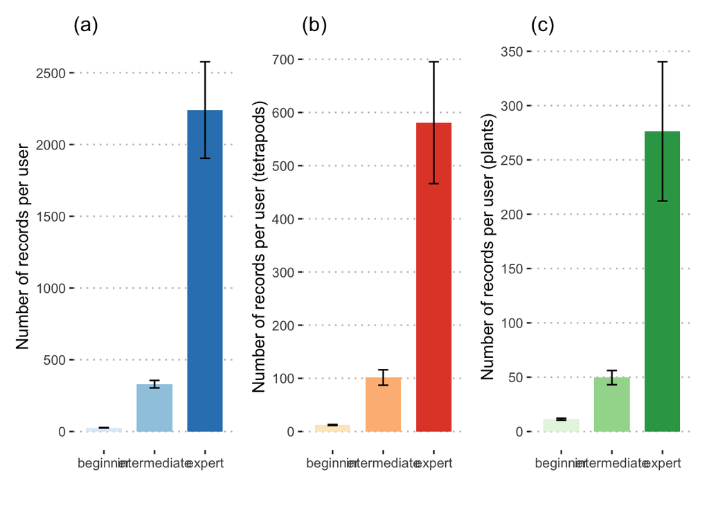

```r
mean_records_per_user <- observations_dataset %>%
  count(user_category, user_login, name = "n_records") %>%
  group_by(user_category) %>%
  summarise(n_users = n(),
            mean_records = mean(n_records),
            sd_records = sd(n_records),
            se_records = sd_records / sqrt(n_users),
            .groups = "drop") %>%
  mutate(user_category = factor(user_category,
                                levels = c("beginner", "intermediate", "expert"))) %>%
  ggplot(aes(user_category, mean_records)) +
  geom_col(aes(fill =user_category), width = 0.7, show.legend = F) +
  geom_errorbar(aes(ymin = mean_records - se_records,
                    ymax = mean_records + se_records),
                width = 0.2) +
  scale_y_continuous(breaks = scales::breaks_pretty(n = 8)) +
  scale_fill_brewer(palette = 'Blues') +
  labs(x = "", y = "Number of records per user") +
  ggpubr::theme_pubclean() +
  ggtitle('(a)')

mean_records_per_user_tetrapods <- tetrapods %>%
  count(user_category, user_login, name = "n_records") %>%
  group_by(user_category) %>%
  summarise(n_users = n(),
            mean_records = mean(n_records),
            sd_records = sd(n_records),
            se_records = sd_records / sqrt(n_users),
            .groups = "drop") %>%
  mutate(user_category = factor(user_category,
                                levels = c("beginner", "intermediate", "expert"))) %>%
  ggplot(aes(user_category, mean_records)) +
  geom_col(aes(fill =user_category), width = 0.7, show.legend = F) +
  geom_errorbar(aes(ymin = mean_records - se_records,
                    ymax = mean_records + se_records),
                width = 0.2) +
  scale_y_continuous(breaks = scales::breaks_pretty(n = 8)) +
  scale_fill_brewer(palette = 'OrRd') +
  labs(x = "", y = "Number of records per user (tetrapods)") +
  ggpubr::theme_pubclean() +
  ggtitle('(b)')


mean_records_per_user_plants <- plants %>%
  count(user_category, user_login, name = "n_records") %>%
  group_by(user_category) %>%
  summarise(n_users = n(),
            mean_records = mean(n_records),
            sd_records = sd(n_records),
            se_records = sd_records / sqrt(n_users),
            .groups = "drop") %>%
  mutate(user_category = factor(user_category,
                                levels = c("beginner", "intermediate", "expert"))) %>%
  ggplot(aes(user_category, mean_records)) +
  geom_col(aes(fill =user_category), width = 0.7, show.legend = F) +
  geom_errorbar(aes(ymin = mean_records - se_records,
                    ymax = mean_records + se_records),
                width = 0.2) +
  scale_y_continuous(breaks = scales::breaks_pretty(n = 8)) +
  scale_fill_brewer(palette = 'Greens') +
  labs(x = "", y = "Number of records per user (plants)") +
  ggpubr::theme_pubclean() +
  ggtitle('(c)')

mean_records_per_user + mean_records_per_user_tetrapods + mean_records_per_user_plants
```

### Tetrapods

```r
tetrapods %>%
  group_by(dist_class) %>%
  summarise(n = n()) %>%
  mutate(freq = scales::label_percent(accuracy=1)(n/sum(n))) %>%
  rename(`distribution area` = dist_class,
         `observations` = n,
         `%` = freq) %>%
  kableExtra::kbl(format.args = list(decimal.mark = '.',
                                     big.mark = ","),
                  digits=2,
                  booktabs = T) %>%
  kableExtra::kable_styling(latex_options = c('striped', 'hold_position'))
```

Classification of species by distribution area

| distribution area | observations | % |
| --- | --- | --- |
| medium | 2,970 | 13% |
| narrow | 1,115 | 5% |
| wide | 18,833 | 82% |

```r
tetrapods %>%
    group_by(user_category, dist_class) %>%
    summarise(n = n()) %>%
    mutate(freq = scales::label_percent(accuracy=1)(n/sum(n))) %>%
   pivot_wider(names_from ='user_category',
               values_from = c('n', 'freq'))%>%
  kableExtra::kbl(format.args = list(decimal.mark = '.',
                                     big.mark = ","),
                  digits=2,
                  booktabs = T) %>%
  kableExtra::kable_styling(latex_options = c('striped', 'hold_position'))
```

Species’ distribution area by user category

| dist_class | n_expert | n_intermediate | n_beginner | freq_expert | freq_intermediate | freq_beginner |
| --- | --- | --- | --- | --- | --- | --- |
| medium | 1,773 | 881 | 316 | 15% | 11% | 10% |
| narrow | 646 | 333 | 136 | 6% | 4% | 4% |
| wide | 9,197 | 6,909 | 2,727 | 79% | 85% | 86% |

```r
tetrapods %>%
    group_by(size_class) %>%
    summarise(n = n()) %>%
    mutate(freq = scales::label_percent(accuracy=1)(n/sum(n)))%>%
    rename(`body size` = size_class,
         `observations` = n,
         `%` = freq) %>%
  kableExtra::kbl(format.args = list(decimal.mark = '.',
                                     big.mark = ","),
                  digits=2,
                  booktabs = T) %>%
  kableExtra::kable_styling(latex_options = c('striped', 'hold_position'))
```

Classification of species by size

| body size | observations | % |
| --- | --- | --- |
| large | 4,449 | 19% |
| medium | 9,802 | 43% |
| small | 8,667 | 38% |

```r
tetrapods %>%
    group_by(user_category, size_class) %>%
    summarise(n = n()) %>%
    mutate(freq = scales::label_percent(accuracy=1)(n/sum(n))) %>%
   pivot_wider(names_from ='user_category',
               values_from = c('n', 'freq')) %>%
  kableExtra::kbl(format.args = list(decimal.mark = '.',
                                     big.mark = ","),
                  digits=2,
                  booktabs = T) %>%
  kableExtra::kable_styling(latex_options = c('striped', 'hold_position'))
```

Species’ size by user category

| size_class | n_expert | n_intermediate | n_beginner | freq_expert | freq_intermediate | freq_beginner |
| --- | --- | --- | --- | --- | --- | --- |
| large | 2,045 | 1,696 | 708 | 18% | 21% | 22% |
| medium | 4,903 | 3,562 | 1,337 | 42% | 44% | 42% |
| small | 4,668 | 2,865 | 1,134 | 40% | 35% | 36% |

```r
tetrapods %>%
    group_by(status) %>%
    summarise(n = n()) %>%
    mutate(freq = scales::label_percent(accuracy=1)(n/sum(n))) %>%
      rename(`conservation satus` = status,
         `observations` = n,
         `%` = freq) %>%
  kableExtra::kbl(format.args = list(decimal.mark = '.',
                                     big.mark = ","),
                  digits=2,
                  booktabs = T) %>%
  kableExtra::kable_styling(latex_options = c('striped', 'hold_position'))
```

Classification of species by conservation status

| conservation satus | observations | % |
| --- | --- | --- |
| CR | 2 | 0% |
| EN | 103 | 0% |
| VU | 334 | 1% |
| NT | 835 | 4% |
| DD | 52 | 0% |
| NE | 901 | 4% |
| LC | 20,691 | 90% |

```r
tetrapods %>%
    group_by(user_category, status) %>%
    summarise(n = n()) %>%
    mutate(freq = scales::label_percent(accuracy=1)(n/sum(n))) %>%
   pivot_wider(names_from ='user_category',
               values_from = c('n', 'freq')) %>%
  kableExtra::kbl(format.args = list(decimal.mark = '.',
                                     big.mark = ","),
                  digits=2,
                  booktabs = T) %>%
  kableExtra::kable_styling(latex_options = c('striped', 'hold_position'))
```

Species’ conservation status by user category

| status | n_expert | n_intermediate | n_beginner | freq_expert | freq_intermediate | freq_beginner |
| --- | --- | --- | --- | --- | --- | --- |
| CR | 1 | NA | 1 | 0% | NA | 0% |
| EN | 70 | 29 | 4 | 1% | 0% | 0% |
| VU | 178 | 104 | 52 | 2% | 1% | 2% |
| NT | 476 | 269 | 90 | 4% | 3% | 3% |
| DD | 16 | 26 | 10 | 0% | 0% | 0% |
| NE | 319 | 394 | 188 | 3% | 5% | 6% |
| LC | 10,556 | 7,301 | 2,834 | 91% | 90% | 89% |

### Plants

```r
##### PLANTS

plants %>%
    group_by(dist_class) %>%
    summarise(n = n()) %>%
    mutate(freq = scales::label_percent(accuracy=1)(n/sum(n))) %>%
  rename(`distribution area` = dist_class,
         `observations` = n,
         `%` = freq) %>%
  kableExtra::kbl(format.args = list(decimal.mark = '.',
                                     big.mark = ","),
                  digits=2,
                  booktabs = T) %>%
  kableExtra::kable_styling(latex_options = c('striped', 'hold_position'))
```

Classification of species by distribution area

| distribution area | observations | % |
| --- | --- | --- |
| medium | 6,324 | 58% |
| narrow | 4,283 | 40% |
| wide | 214 | 2% |

```r
plants %>%
    group_by(user_category, dist_class) %>%
    summarise(n = n()) %>%
    mutate(freq = scales::label_percent(accuracy=1)(n/sum(n))) %>%
   pivot_wider(names_from ='user_category',
               values_from = c('n', 'freq')) %>%
  kableExtra::kbl(format.args = list(decimal.mark = '.',
                                     big.mark = ","),
                  digits=2,
                  booktabs = T) %>%
  kableExtra::kable_styling(latex_options = c('striped', 'hold_position'))
```

Species’ distribution area by user category

| dist_class | n_expert | n_intermediate | n_beginner | freq_expert | freq_intermediate | freq_beginner |
| --- | --- | --- | --- | --- | --- | --- |
| medium | 2,886 | 2,130 | 1,308 | 58% | 60% | 57% |
| narrow | 1,968 | 1,385 | 930 | 40% | 39% | 41% |
| wide | 118 | 57 | 39 | 2% | 2% | 2% |

```r
plants %>%
    group_by(growth) %>%
    summarise(n = n()) %>%
    mutate(freq = scales::label_percent(accuracy=1)(n/sum(n))) %>%
    rename(`growth form` = growth,
         `observations` = n,
         `%` = freq) %>%
  kableExtra::kbl(format.args = list(decimal.mark = '.',
                                     big.mark = ","),
                  digits=2,
                  booktabs = T) %>%
  kableExtra::kable_styling(latex_options = c('striped', 'hold_position'))
```

Classification of species by size

| growth form | observations | % |
| --- | --- | --- |
| herb | 6,435 | 59% |
| vine | 116 | 1% |
| liana | 75 | 1% |
| subshrub | 1,278 | 12% |
| shrub | 2,173 | 20% |
| tree | 744 | 7% |

```r
plants %>%
    group_by(user_category, growth) %>%
    summarise(n = n()) %>%
    mutate(freq = scales::label_percent(accuracy=1)(n/sum(n))) %>%
   pivot_wider(names_from ='user_category',
               values_from = c('n', 'freq')) %>%
  kableExtra::kbl(format.args = list(decimal.mark = '.',
                                     big.mark = ","),
                  digits=2,
                  booktabs = T) %>%
  kableExtra::kable_styling(latex_options = c('striped', 'hold_position'))
```

Species’ size by user category

| growth | n_expert | n_intermediate | n_beginner | freq_expert | freq_intermediate | freq_beginner |
| --- | --- | --- | --- | --- | --- | --- |
| herb | 3,034 | 2,069 | 1,332 | 61% | 58% | 58% |
| vine | 58 | 32 | 26 | 1% | 1% | 1% |
| liana | 32 | 25 | 18 | 1% | 1% | 1% |
| subshrub | 622 | 379 | 277 | 13% | 11% | 12% |
| shrub | 955 | 757 | 461 | 19% | 21% | 20% |
| tree | 271 | 310 | 163 | 5% | 9% | 7% |

```r
plants %>%
    group_by(status) %>%
    summarise(n = n()) %>%
    mutate(freq = scales::label_percent(accuracy=1)(n/sum(n))) %>%
  rename(`conservation status` = status,
         `observations` = n,
         `%` = freq) %>%
  kableExtra::kbl(format.args = list(decimal.mark = '.',
                                     big.mark = ","),
                  digits=2,
                  booktabs = T) %>%
  kableExtra::kable_styling(latex_options = c('striped', 'hold_position'))
```

Classification of species by conservation status

| conservation status | observations | % |
| --- | --- | --- |
| CR | 4 | 0% |
| EN | 23 | 0% |
| VU | 259 | 2% |
| NT | 12 | 0% |
| DD | 4 | 0% |
| NE | 8,633 | 80% |
| LC | 1,886 | 17% |

```r
plants %>%
    group_by(user_category, status) %>%
    summarise(n = n()) %>%
    mutate(freq = scales::label_percent(accuracy=1)(n/sum(n))) %>%
   pivot_wider(names_from ='user_category',
               values_from = c('n', 'freq')) %>%
  kableExtra::kbl(format.args = list(decimal.mark = '.',
                                     big.mark = ","),
                  digits=2,
                  booktabs = T) %>%
  kableExtra::kable_styling(latex_options = c('striped', 'hold_position'))
```

Species’ conservation status by user category

| status | n_expert | n_intermediate | n_beginner | freq_expert | freq_intermediate | freq_beginner |
| --- | --- | --- | --- | --- | --- | --- |
| EN | 11 | 9 | 3 | 0% | 0% | 0% |
| VU | 161 | 61 | 37 | 3% | 2% | 2% |
| NT | 3 | 8 | 1 | 0% | 0% | 0% |
| DD | 1 | 1 | 2 | 0% | 0% | 0% |
| NE | 3,978 | 2,825 | 1,830 | 80% | 79% | 80% |
| LC | 818 | 664 | 404 | 16% | 19% | 18% |
| CR | NA | 4 | NA | NA | 0% | NA |

### Plots

#### Per group and user category

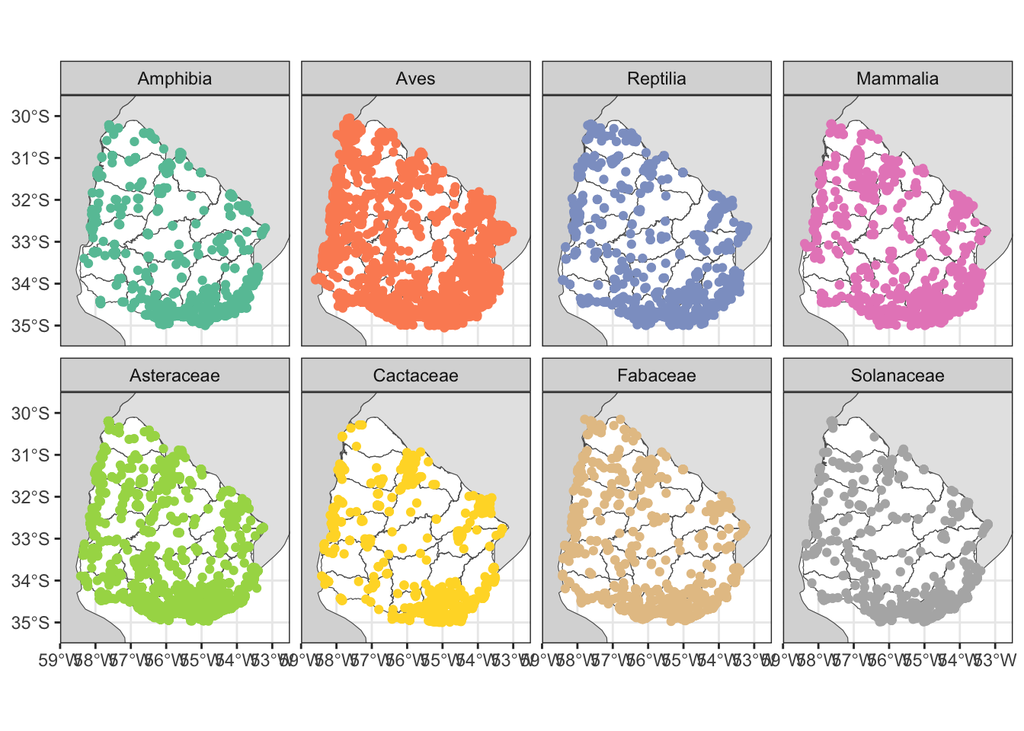

```r
data_sf <- bind_rows(tetrapods,plants) %>%
  sf::st_as_sf(coords=c('longitude', 'latitude')) %>%
  sf::st_set_crs(4326) %>%
  mutate(taxon = factor(taxon, levels = c('Amphibia', 'Aves',
                                          'Reptilia', 'Mammalia',
                                          'Asteraceae', 'Cactaceae',
                                          'Fabaceae', 'Solanaceae')))

uruguay_dptos <- readRDS('data/Uruguay.rds') %>% st_transform(4326)

argentina <- rnaturalearth::ne_countries(country = 'argentina', scale=50)
brazil <- rnaturalearth::ne_countries(country = 'brazil', scale=50)
southamerica <- rnaturalearth::ne_countries(continent = 'south america', scale=50)

ggplot() +
  geom_sf(data=uruguay_dptos, fill='white') +
  geom_sf(data=argentina, fill='grey85') +
  geom_sf(data=brazil, fill='grey90') +
  geom_sf(data=data_sf %>% filter(taxon %in% c('Amphibia',
                                               'Aves',
                                               'Mammalia',
                                               'Reptilia')),
          aes(col=taxon), show.legend = F) +
  geom_sf(data=data_sf %>% filter(taxon %in% c('Asteraceae',
                                               'Cactaceae',
                                               'Fabaceae',
                                               'Solanaceae')),
          aes(col=taxon), show.legend = F) +
  scale_color_brewer(palette = 'Set2') +
  coord_sf(xlim = c(-59, -52.5), ylim = c(-35.5, -29.5), expand = FALSE) +
  facet_wrap(~taxon, ncol = 4, ) +
  theme_bw()
```

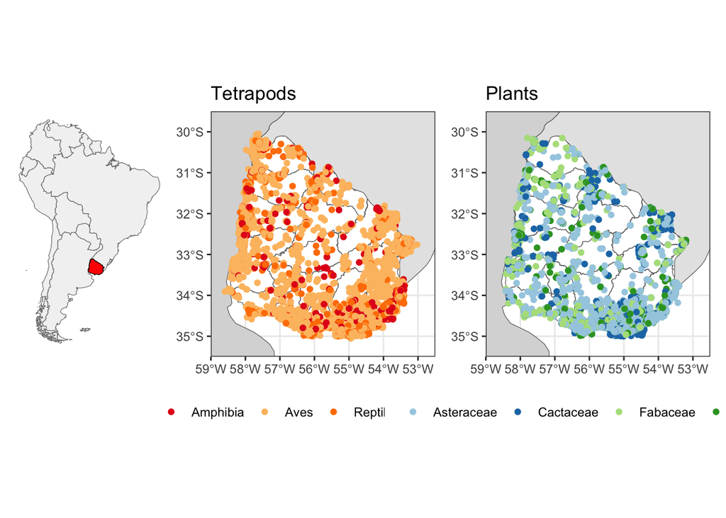

```r
southamerica_map <- ggplot() +
  geom_sf(data=southamerica, fill='grey95', col='grey45') +
  geom_sf(data=st_union(uruguay_dptos), fill='red') +
  coord_sf(xlim = c(-85, -32), ylim = c(-60, 15), expand = FALSE) +
  theme_void()

tetra_map <- ggplot() +
  geom_sf(data=uruguay_dptos, fill='white') +
  geom_sf(data=argentina, fill='grey85') +
  geom_sf(data=brazil, fill='grey90') +
  geom_sf(data=data_sf %>% filter(taxon %in% c('Amphibia',
                                               'Aves',
                                               'Mammalia',
                                               'Reptilia')),
          aes(col=taxon)) +
  # scale_color_brewer(palette = 'Paired') +
  scale_color_manual(values = RColorBrewer::brewer.pal(n = 8, name = "Paired")[6:9]) +
  coord_sf(xlim = c(-59, -52.5), ylim = c(-35.5, -29.5), expand = FALSE) +
  theme_bw() + labs(col='', title = 'Tetrapods') +
  theme(legend.position = 'bottom')


plants_map <- ggplot() +
  geom_sf(data=uruguay_dptos, fill='white') +
  geom_sf(data=argentina, fill='grey85') +
  geom_sf(data=brazil, fill='grey90') +
  geom_sf(data=data_sf %>% filter(taxon %in% c('Asteraceae',
                                               'Cactaceae',
                                               'Fabaceae',
                                               'Solanaceae')),
          aes(col=taxon)) +
  scale_color_brewer(palette = 'Paired') +
  coord_sf(xlim = c(-59, -52.5), ylim = c(-35.5, -29.5), expand = FALSE) +
  theme_bw() + labs(col='', title = 'Plants') +
  theme(legend.position = 'bottom')

southamerica_map | tetra_map | plants_map
```

```r
# ggsave(file='figs/observations_maps.svg',
#        plot=(southamerica_map | tetra_map | plants_map),
#        width=12, height=5, dpi = 100)
```

#### Spatial coverage (grids)

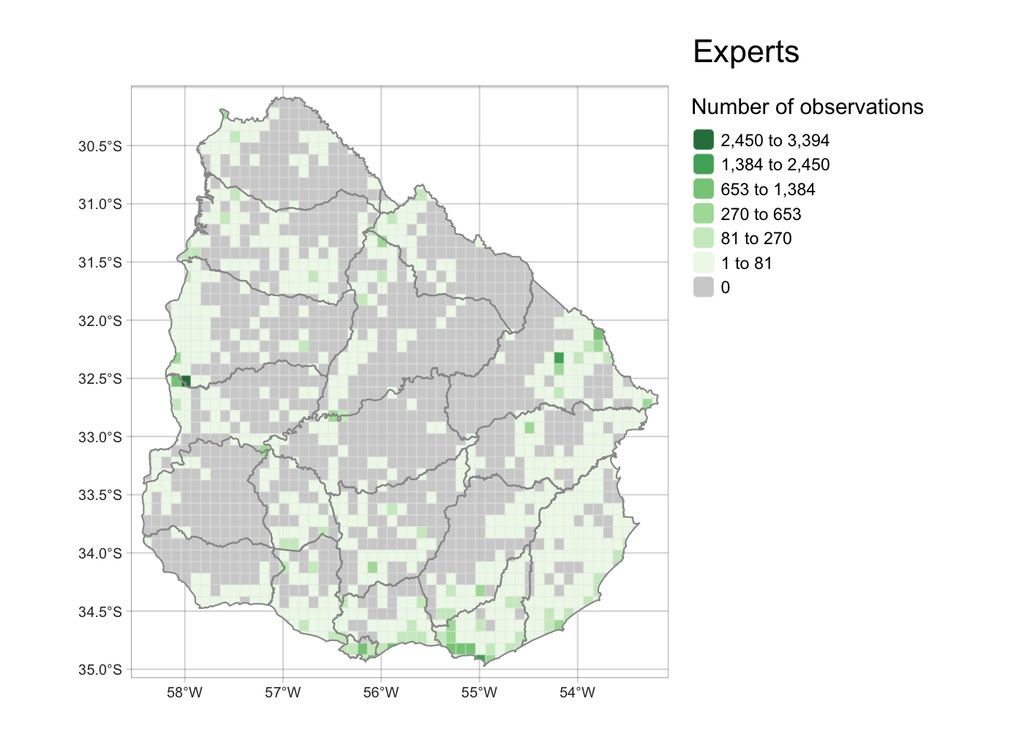

```r
# create grid
uruguay_grid <- st_make_grid(st_union(uruguay_dptos), 0.1) %>%
  st_intersection(st_union(uruguay_dptos)) %>%
  st_sf(grid_id=1:length(.), geometry= .) %>%
  st_make_valid() %>% st_cast()

# convert observations to an sf object
observations_dataset_sf <- observations_dataset %>%
  sf::st_as_sf(coords=c('longitude', 'latitude')) %>%
  sf::st_set_crs(4326) %>%
  mutate(user_category = factor(user_category,
                                levels = c('beginner',
                                           'intermediate',
                                           'expert')))

expert_grid <- st_join(uruguay_grid,
                       observations_dataset_sf %>%
                         filter(user_category=='expert')) %>%
  group_by(grid_id) %>%
  summarise(n_observations=ifelse(n_distinct(taxon_species_name,
                                             na.rm=T)!=0, n(), 0)) %>%
  st_cast()

intermediate_grid <- st_join(uruguay_grid,
                             observations_dataset_sf %>%
                               filter(user_category=='intermediate')) %>%
  group_by(grid_id) %>%
  summarise(n_observations=ifelse(n_distinct(taxon_species_name,
                                             na.rm=T)!=0, n(), 0)) %>%
  st_cast()

beginner_grid <- st_join(uruguay_grid,
                         observations_dataset_sf %>%
                           filter(user_category=='beginner')) %>%
  group_by(grid_id) %>%
  summarise(n_observations=ifelse(n_distinct(taxon_species_name,
                                             na.rm=T)!=0, n(), 0)) %>%
  st_cast()


coverage <- tibble(experts = expert_grid %>%
                     st_drop_geometry() %>%
                     summarise(coverage=sum(n_observations>0) * 100 / n()) %>%
                     pull,
                   intermediates =  intermediate_grid %>%
                     st_drop_geometry() %>%
                     summarise(coverage=sum(n_observations>0) * 100 / n()) %>%
                     pull,
                   beginners = beginner_grid %>% st_drop_geometry() %>%
                     summarise(coverage=sum(n_observations>0) * 100 / n()) %>%
                     pull)

experts_map <- tm_graticules(alpha = 0.3) +
  tm_shape(expert_grid %>%
             mutate(n_observations=ifelse(n_observations==0,
                                          NA, n_observations))) +
  tm_polygons(fill='n_observations', fill_alpha = 0.9,
              col='grey90', col_alpha = 0.2,
              fill.scale = tm_scale_intervals(n = 6,
                                              style = 'jenks',
                                              values = 'brewer.greens',
                                              value.na = 'grey80',
                                              label.na = '0'),
              fill.legend = tm_legend(item.space = 0, item.na.space = 0,
                                      title = 'Number of observations',
                                      reverse = T, frame = F)) +
  tm_shape(uruguay_dptos) +
  tm_borders(col='grey60', fill_alpha = 0.4) +
  tm_layout(legend.outside = T, frame.lwd = 0.2, frame.r = 0) +
  # tm_credits(paste0(round(coverage$experts,0),
  #                   '% cells covered'), position = c(0.6,0.9), size=1) +
  tm_title('Experts', position = tm_pos_out('right', 'top'))

intermediates_map <- tm_graticules(alpha = 0.3) +
  tm_shape(intermediate_grid %>%
             mutate(n_observations=ifelse(n_observations==0,
                                          NA, n_observations))) +
  tm_polygons(fill='n_observations', fill_alpha = 0.9,
              col='grey90', col_alpha = 0.2,
              fill.scale = tm_scale_intervals(n = 6,
                                              style = 'jenks',
                                              values = 'brewer.reds',
                                              value.na = 'grey80',
                                              label.na = '0'),
              fill.legend = tm_legend(item.space = 0, item.na.space = 0,
                                      title = 'Number of observations',
                                      reverse = T, frame = F)) +
  tm_shape(uruguay_dptos) +
  tm_borders(col='grey60', fill_alpha = 0.4) +
  tm_layout(legend.outside = T, frame.lwd = 0.2, frame.r = 0) +
  # tm_credits(paste0(round(coverage$intermediates,0),
  #                   '% cells covered'), position = c(0.6,0.9), size=1) +
  tm_title('Intermediates', position = tm_pos_out('right', 'top'))

beginners_map <- tm_graticules(alpha = 0.3) +
  tm_shape(beginner_grid %>%
             mutate(n_observations=ifelse(n_observations==0,
                                          NA, n_observations))) +
  tm_polygons(fill='n_observations', fill_alpha = 0.9,
              col='grey90', col_alpha = 0.2,
              fill.scale = tm_scale_intervals(n = 6,
                                              style = 'jenks',
                                              values = 'brewer.blues',
                                              value.na = 'grey80',
                                              label.na = '0'),
              fill.legend = tm_legend(item.space = 0, item.na.space = 0,
                                      title = 'Number of observations',
                                      reverse = T, frame = F)) +
  tm_shape(uruguay_dptos) +
  tm_borders(col='grey60', fill_alpha = 0.4) +
  tm_layout(legend.outside = T, frame.lwd = 0.2, frame.r = 0) +
  # tm_credits(paste0(round(coverage$beginners,0),
  #                   '% cells covered'), position = c(0.6,0.9), size=1) +
  tm_title('Beginners', position = tm_pos_out('right', 'top'))

experts_map
```

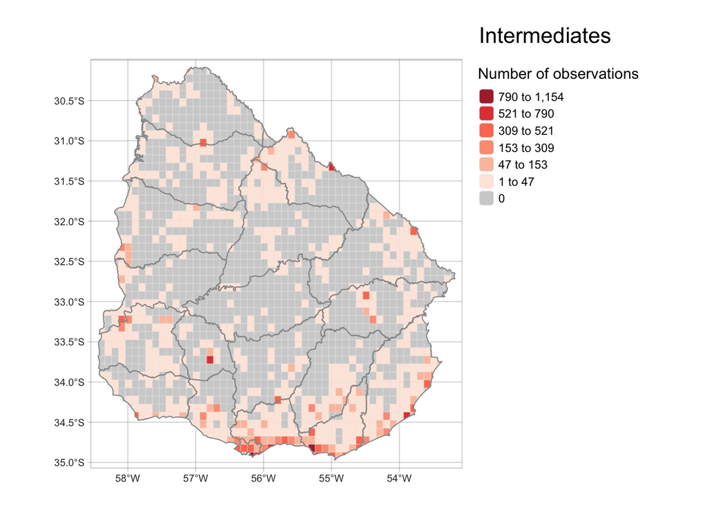

```r
intermediates_map
```

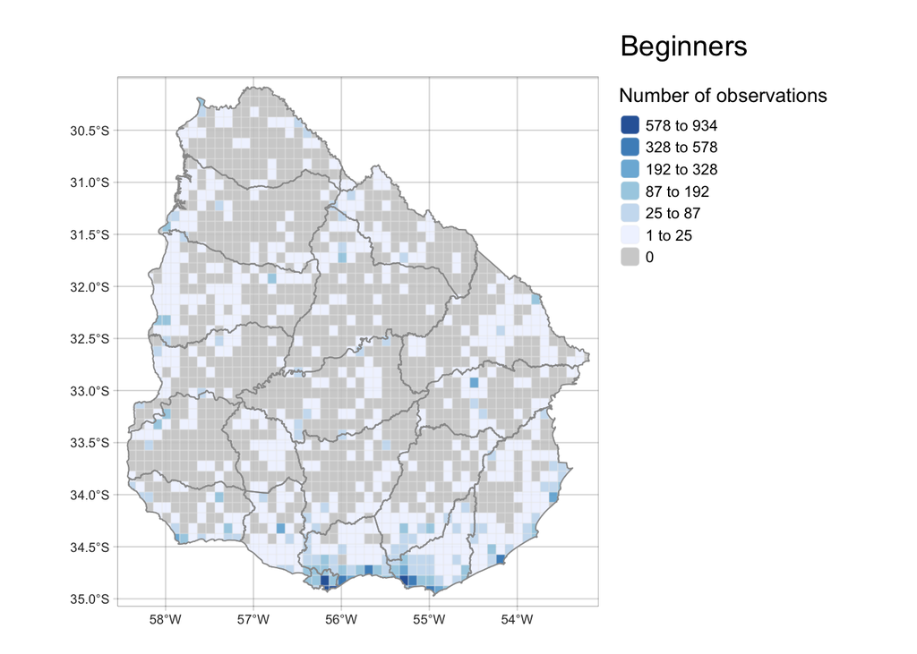

```r
beginners_map
```

```r
# tmap_save(tm = experts_map, width = 8, height = 6,
#           filename = 'figs/experts_grid.svg', dpi = 100)
# tmap_save(tm = intermediates_map, width = 8, height = 6,
#           filename = 'figs/intermediates_grid.svg', dpi = 100)
# tmap_save(tm = beginners_map, width = 8, height = 6,
#           filename = 'figs/beginners_grid.svg', dpi = 100)

coverage %>%
  mutate(experts = scales::percent(experts/100, accuracy=1)) %>%
  mutate(intermediates = scales::percent(intermediates/100, accuracy=1)) %>%
  mutate(beginners = scales::percent(beginners/100, accuracy=1)) %>%
  kableExtra::kbl(format.args = list(decimal.mark = '.',
                                     big.mark = ","),
                  digits=2,
                  booktabs = T) %>%
  kableExtra::kable_styling(latex_options = c('striped', 'hold_position'))
```

Percentage of geographic coverage by user category

| experts | intermediates | beginners |
| --- | --- | --- |
| 42% | 39% | 41% |

#### Traits

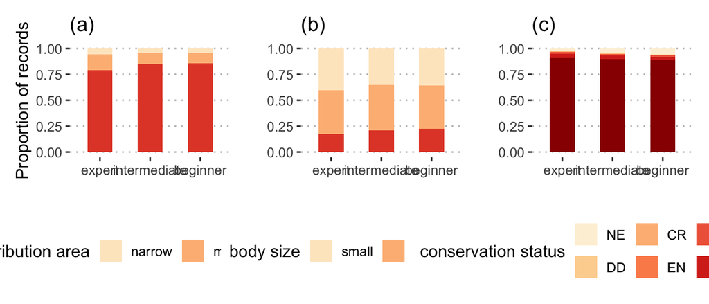

```r
##### TETRAPODS

# distribution
tetra_plot_distribution <- tetrapods %>%
  group_by(user_category, dist_class) %>% count() %>%
  ggplot(aes(x=user_category, y=n, fill= factor(dist_class,
                                     levels = c('narrow', 'medium', 'wide')))) +
  geom_bar(width = 0.5, stat = 'identity', show.legend = T,
           position = 'fill') +
  labs(x='', y='Proportion of records', fill = 'distribution') +
  scale_fill_brewer(palette = 'OrRd', name='distribution area') +
 ggpubr::theme_pubclean() + theme(legend.position = 'bottom') +
  ggtitle('(a)')

# size
tetra_plot_size <- tetrapods %>%
  group_by(user_category, size_class) %>% count() %>%
  ggplot(aes(x=user_category, y=n, fill= factor(size_class,
                                     levels = c('small', 'medium', 'large')))) +
  geom_bar(width = 0.5, stat = 'identity', show.legend = T,
           position = 'fill') +
  labs(x='', y='', fill = 'size') +
  scale_fill_brewer(palette = 'OrRd', name='body size') +
  ggpubr::theme_pubclean() + theme(legend.position = 'bottom')  +
  ggtitle('(b)')


# conservation status
tetra_plot_status <- tetrapods %>%
  group_by(user_category, status) %>% count() %>%
  ggplot(aes(x=user_category, y=n, fill= factor(status,
  levels = c('NE', 'DD', 'CR', 'EN', 'VU', 'NT', 'LC')))) +
  geom_bar(width = 0.5, stat = 'identity', show.legend = T,
           position = 'fill') +
  labs(x='', y='', fill = 'IUCNglobal') +
  scale_fill_brewer(palette = 'OrRd', name='conservation status') +
  ggpubr::theme_pubclean() + theme(legend.position = 'bottom')  +
  ggtitle('(c)')

tetra_plots <- tetra_plot_distribution | tetra_plot_size | tetra_plot_status

tetra_plots
```

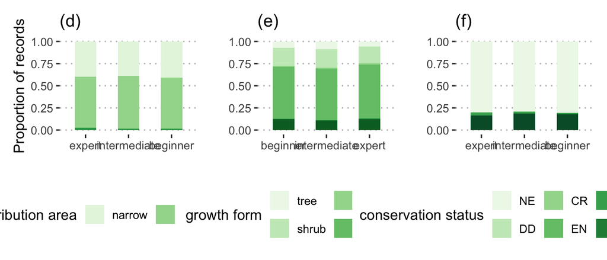

```r
# ggsave(tetra_plots, dpi = 100,
#        width = 18, height = 7, scale = 0.8,
#        file = 'figs/Figure_4.svg')

##### PLANTS

# distribution
plants_plot_distribution <- plants %>%
  group_by(user_category, dist_class) %>% count() %>%
  ggplot(aes(x=user_category, y=n, fill= factor(dist_class,
                                     levels = c('narrow', 'medium', 'wide')))) +
  geom_bar(width = 0.5, stat = 'identity', show.legend = T,
           position = 'fill') +
  labs(x='', y='Proportion of records', fill = 'distribution') +
  scale_fill_brewer(palette = 'Greens', name='distribution area') +
 ggpubr::theme_pubclean() + theme(legend.position = 'bottom') +
  ggtitle('(d)')

# size
plants_plot_growth <- plants %>%
  mutate(growth = factor(growth,
                              levels = c('tree',
                                         'shrub',
                                         'vine', 'herb',
                                         'liana', 'subshrub')),
         user_category = factor(user_category,
                                levels = c('beginner',
                                           'intermediate',
                                           'expert'))) %>%
  group_by(user_category, growth) %>%
  count() %>%
  ggplot(aes(x = user_category, y = n, fill = growth)) +
  geom_bar(width = 0.5, stat = "identity", show.legend = TRUE, position = "fill") +
  labs(x = "", y = "", fill = "growth form") +
  scale_fill_brewer(palette = 'Greens', name='growth form') +
 ggpubr::theme_pubclean() + theme(legend.position = 'bottom') +
  ggtitle('(e)')


# conservation status
plants_plot_status <- plants %>%
  group_by(user_category, status) %>% count() %>%
  ggplot(aes(x=user_category, y=n, fill= factor(status,
  levels = c('NE', 'DD', 'CR', 'EN', 'VU', 'NT', 'LC')))) +
  geom_bar(width = 0.5, stat = 'identity', show.legend = T,
           position = 'fill') +
  labs(x='', y='', fill = 'IUCNglobal') +
  scale_fill_brewer(palette = 'Greens', name='conservation status') +
  ggpubr::theme_pubclean() + theme(legend.position = 'bottom') +
  ggtitle('(f)')


plants_plots <- plants_plot_distribution | plants_plot_growth | plants_plot_status

plants_plots
```

```r
# ggsave(plants_plots, dpi = 100,
#        width = 18, height = 7, scale = 0.8,
#        file = 'figs/Figure_5.svg')
```

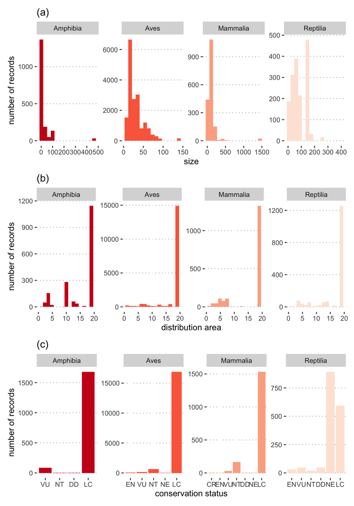

```r
##### TETRAPODS

# size plot
supp_size_plot <- ggplot(data = tetrapods, aes(x = size, fill=taxon)) +
  geom_histogram(position = 'identity',
                 bins = 15, show.legend = F) +
  facet_wrap(taxon~., scales = 'free', ncol = 4) +
  scale_fill_brewer(palette = 'Reds', direction = -1) +
  ggpubr::theme_pubclean() +
  labs(x= 'size', y='number of records') +
  ggtitle('(a)')

# distribution plot
supp_distribution_plot <- ggplot(data = tetrapods, aes(x = dist, fill=taxon)) +
  geom_histogram(position = 'identity',
                 bins = 15, show.legend = F) +
  facet_wrap(taxon~., scales = 'free', ncol = 4) +
  scale_fill_brewer(palette = 'Reds', direction = -1) +
  ggpubr::theme_pubclean() +
  labs(x= 'distribution area', y='number of records') +
  ggtitle('(b)')

# conservation status plot
supp_status_plot <- ggplot(data = tetrapods, aes(x = status, fill=taxon)) +
  geom_histogram(stat = 'count', show.legend = F) +
  facet_wrap(taxon~., scales = 'free', ncol = 4) +
  scale_fill_brewer(palette = 'Reds', direction = -1) +
  ggpubr::theme_pubclean() +
  labs(x= 'conservation status', y='number of records') +
  ggtitle('(c)')

supp_tetra_plots <- supp_size_plot / supp_distribution_plot / supp_status_plot

supp_tetra_plots
```

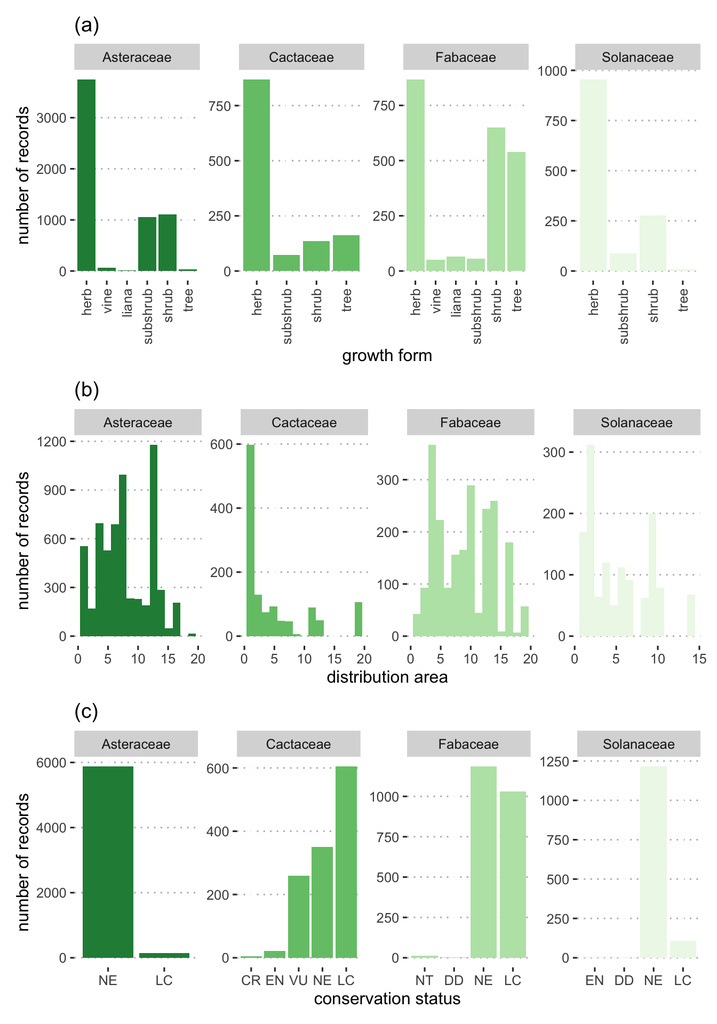

```r
# ggsave(supp_tetra_plots, dpi = 100,
#        width = 10, height = 15, scale = 0.8,
#        file = 'figs/Figure_S2.svg')


##### PLANTS

# growth plot
supp_growth_plot <- ggplot(data = plants, aes(x = growth, fill=taxon)) +
  geom_histogram(stat = 'count', show.legend = F) +
  facet_wrap(taxon~., scales = 'free', ncol = 4) +
  scale_fill_brewer(palette = 'Greens', direction = -1) +
  ggpubr::theme_pubclean() +
  labs(x= 'growth form', y='number of records') +
  theme(axis.text.x = element_text(angle = 90, vjust = 0.5, hjust=1)) +
  ggtitle('(a)')

# distribution plot
supp_distribution_plot <- ggplot(data = plants, aes(x = dist, fill=taxon)) +
  geom_histogram(position = 'identity',
                 bins = 15, show.legend = F) +
  facet_wrap(taxon~., scales = 'free', ncol = 4) +
  scale_fill_brewer(palette = 'Greens', direction = -1) +
  ggpubr::theme_pubclean() +
  labs(x= 'distribution area', y='number of records') +
  ggtitle('(b)')

# conservation status plot
supp_status_plot <- ggplot(data = plants, aes(x = status, fill=taxon)) +
  geom_histogram(stat = 'count', show.legend = F) +
  facet_wrap(taxon~., scales = 'free', ncol = 4) +
  scale_fill_brewer(palette = 'Greens', direction = -1) +
  ggpubr::theme_pubclean() +
  labs(x= 'conservation status', y='number of records') +
  ggtitle('(c)')


supp_plants_plots <- supp_growth_plot / supp_distribution_plot / supp_status_plot

supp_plants_plots
```

```r
# ggsave(supp_plants_plots, dpi = 100,
#        width = 10, height = 15, scale = 0.8,
#        file = 'figs/Figure_S3.svg')
```

## Statistical analyses

### Tetrapods

#### Hypothesis 1

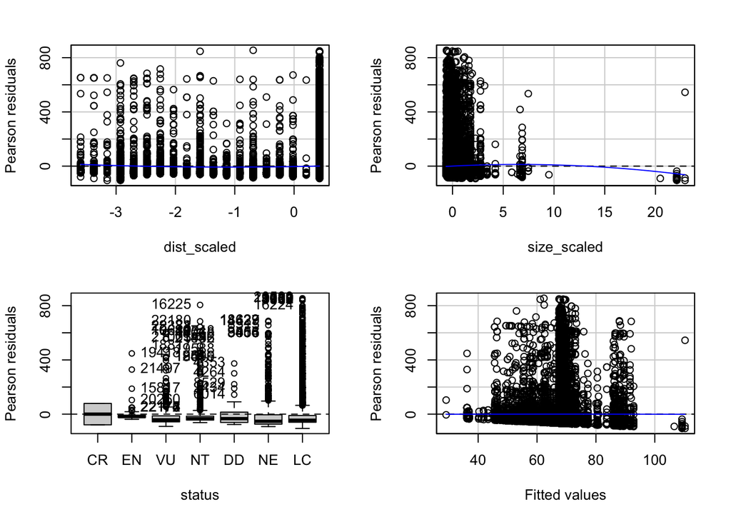

```
            Test stat Pr(>|Test stat|)
dist_scaled    3.0475        0.0023099 **
size_scaled   -3.3552        0.0007945 ***
status
Tukey test    -0.1987        0.8425336
---
Signif. codes:  0 '***' 0.001 '**' 0.01 '*' 0.05 '.' 0.1 ' ' 1
```

```r
mod_tetra <- lm(ranking ~ dist_scaled + size_scaled + status,
                data = tetrapods)

# summary(mod_tetra)

car::residualPlots(mod_tetra)
```

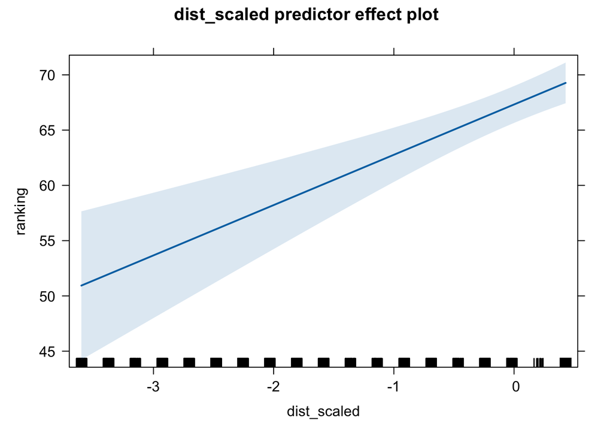

```r
plot(predictorEffect(predictor = 'dist_scaled', mod = mod_tetra))
```

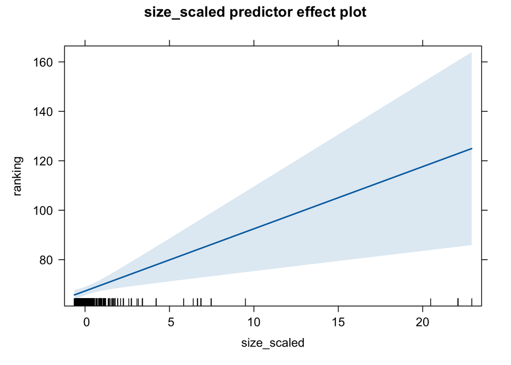

```r
plot(predictorEffect(predictor = 'size_scaled', mod = mod_tetra))
```

#### Hypothesis 2

```r
tapply(tetrapods$dist, INDEX = tetrapods$user_category, mean)
```

```
      expert intermediate     beginner
    16.77023     17.38902     17.43221
```

```r
tapply(tetrapods$dist, INDEX = tetrapods$user_category, sd)
```

```
      expert intermediate     beginner
    4.766938     4.124072     4.101917
```

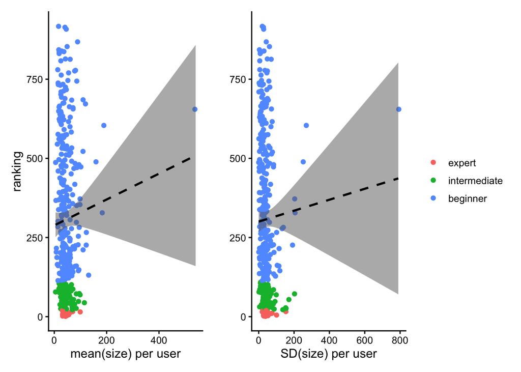

```r
mod_tetra_user_mean <- lm(ranking ~ mean_size + mean_dist,
                          data = tetrapods_per_user)
# summary(mod_tetra_user_mean)

mod_tetra_user_sd <- lm(ranking ~ sd_dist + sd_size,
                        data = tetrapods_per_user)
# summary(mod_tetra_user_sd)

pred_mod_tetra_user_mean <- as.data.frame(predictorEffects(mod =
                                 lm(ranking ~ mean_dist + mean_size,
                                    data = tetrapods_per_user)))

plot_pred_mean_dist <- ggplot(data = pred_mod_tetra_user_mean$mean_dist,
       aes(x = mean_dist, y = fit)) +
  geom_point(data = tetrapods_per_user,
             aes(y = ranking, x = mean_dist, col=user_category),
             show.legend = F) +
  geom_ribbon(aes(ymin = lower, ymax = upper),
              fill='grey40', alpha=0.5) +
  geom_line(col='black', linewidth=1, linetype = 'dashed') +
  labs(y='ranking', x='mean(distribution) per user', col='') +
  # ylim(c(0,600))+
  ggpubr::theme_classic2()

plot_pred_mean_size <- ggplot(data = pred_mod_tetra_user_mean$mean_size,
       aes(x = mean_size, y = fit)) +
  geom_point(data = tetrapods_per_user,
             aes(y = ranking, x = mean_size, col=user_category),
             show.legend = F) +
  geom_ribbon(aes(ymin = lower, ymax = upper),
              fill='grey40', alpha=0.5) +
  geom_line(col='black', linewidth=1, linetype = 'dashed') +
  labs(y='ranking', x='mean(size) per user', col='') +
  # ylim(c(0,600))+
  ggpubr::theme_classic2()

pred_mod_tetra_user_sd <- as.data.frame(predictorEffects(mod =
                                 lm(ranking ~ sd_dist + sd_size,
                                    data = tetrapods_per_user)))

plot_pred_sd_dist <- ggplot(data = pred_mod_tetra_user_sd$sd_dist,
       aes(x = sd_dist, y = fit)) +
  geom_point(data = tetrapods_per_user,
             aes(y = ranking, x = sd_dist, col=user_category)) +
  geom_ribbon(aes(ymin = lower, ymax = upper),
              fill='grey40', alpha=0.5) +
  geom_line(col='black', linewidth=1, linetype = 'dashed') +
  labs(y='', x='SD(distribution) per user', col='') +
  # ylim(c(0,600))+
  ggpubr::theme_classic2()

plot_pred_sd_size <- ggplot(data = pred_mod_tetra_user_sd$sd_size,
       aes(x = sd_size, y = fit)) +
  geom_point(data = tetrapods_per_user,
             aes(y = ranking, x = sd_size, col=user_category)) +
  geom_ribbon(aes(ymin = lower, ymax = upper),
              fill='grey40', alpha=0.5) +
  geom_line(col='black', linewidth=1, linetype = 'dashed') +
  labs(y='', x='SD(size) per user', col='') +
  # ylim(c(0,600))+
  ggpubr::theme_classic2()

plot_pred_mean_size | plot_pred_sd_size
```

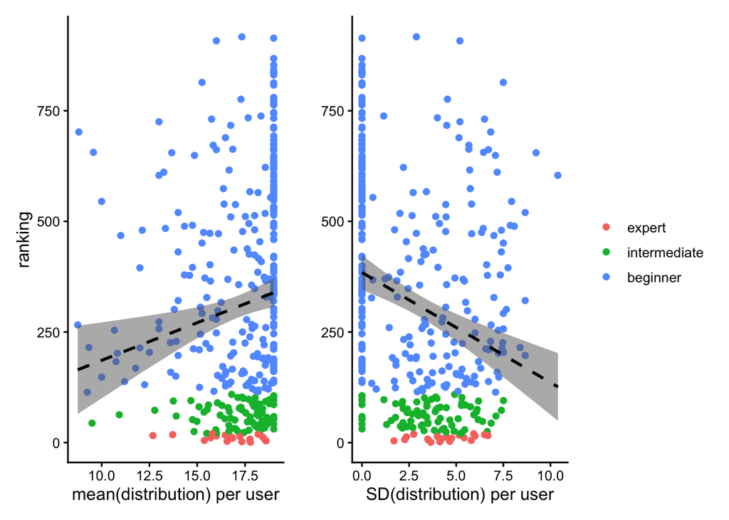

```r
plot_pred_mean_dist | plot_pred_sd_dist
```

### Models’ summary

```r
stargazer(mod_tetra, mod_tetra_user_mean, mod_tetra_user_sd,
          ci = T, digits=1,
          type='html',
          title = 'tetrapods')
```

**tetrapods**

|  | *Dependent variable:* |  |  |
| --- | --- | --- | --- |
|  | ranking |  |  |
|  | (1) | (2) | (3) |
| dist_scaled | 4.6*** |  |  |
|  | (2.7, 6.4) |  |  |
| size_scaled | 2.5*** |  |  |
|  | (0.8, 4.2) |  |  |
| statusEN | -49.2 |  |  |
|  | (-229.6, 131.3) |  |  |
| statusVU | -25.1 |  |  |
|  | (-204.4, 154.2) |  |  |
| statusNT | -38.1 |  |  |
|  | (-217.1, 140.9) |  |  |
| statusDD | -21.3 |  |  |
|  | (-203.5, 161.0) |  |  |
| statusNE | -10.4 |  |  |
|  | (-189.5, 168.6) |  |  |
| statusLC | -28.6 |  |  |
|  | (-207.4, 150.2) |  |  |
| mean_size |  | 0.4 |  |
|  |  | (-0.3, 1.1) |  |
| mean_dist |  | 17.0*** |  |
|  |  | (5.6, 28.5) |  |
| sd_dist |  |  | -24.9*** |
|  |  |  | (-34.7, -15.0) |
| sd_size |  |  | 0.2 |
|  |  |  | (-0.3, 0.7) |
| Constant | 95.6 | -3.7 | 376.9*** |
|  | (-83.2, 274.4) | (-213.1, 205.8) | (338.3, 415.5) |
| Observations | 22,918 | 358 | 358 |
| R<sup>2</sup> | 0.003 | 0.02 | 0.1 |
| Adjusted R<sup>2</sup> | 0.003 | 0.02 | 0.1 |
| Residual Std. Error | 128.9 (df = 22909) | 239.7 (df = 355) | 234.2 (df = 355) |
| F Statistic | 8.5*** (df = 8; 22909) | 4.3** (df = 2; 355) | 12.9*** (df = 2; 355) |
| *Note:* | *p<0.1; **p<0.05;*** p<0.01 |  |  |

### Plants

#### Hypothesis 1

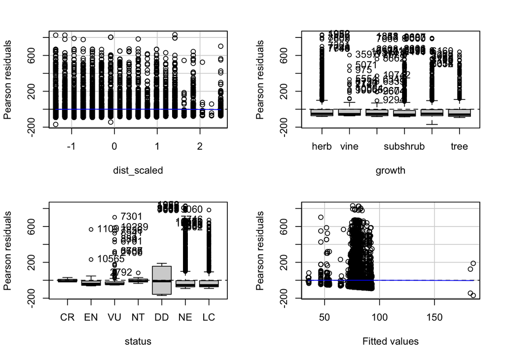

```
            Test stat Pr(>|Test stat|)
dist_scaled    -0.882           0.3778
growth
status
Tukey test     -0.601           0.5478
```

```r
mod_plants <- lm(ranking ~ dist_scaled + growth + status,
                data = plants)
# summary(mod_plants)

car::residualPlots(mod_plants)
```

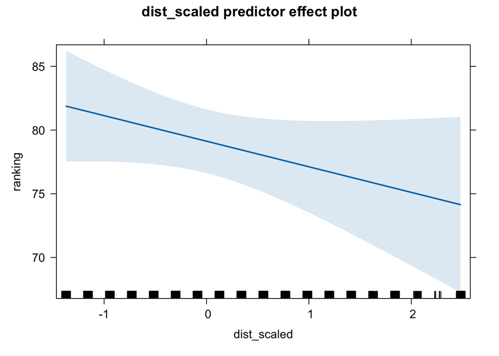

```r
plot(predictorEffect(predictor = 'dist_scaled', mod = mod_plants))
```

#### Hypothesis 2

```r
tapply(plants$dist, INDEX = plants$user_category, mean)
```

```
      expert intermediate     beginner
    7.464803     7.402016     7.282389
```

```r
tapply(plants$dist, INDEX = plants$user_category, sd)
```

```
      expert intermediate     beginner
    4.769118     4.534960     4.649368
```

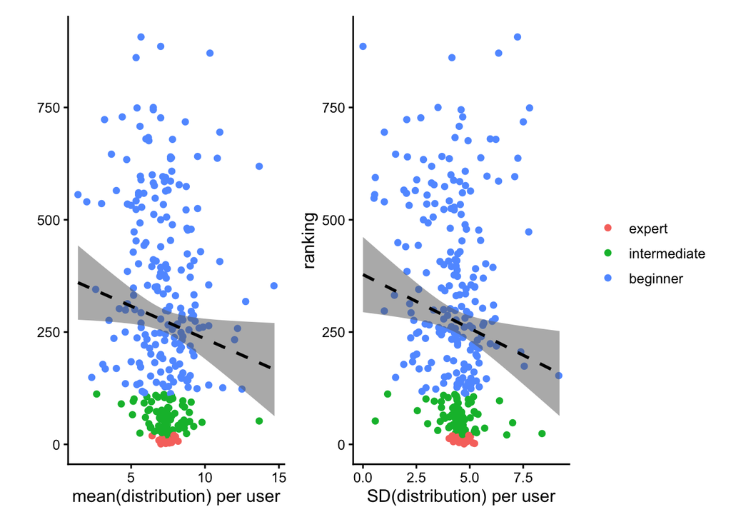

```r
mod_plants_user_mean <- lm(ranking ~ mean_dist,
                          data = plants_per_user)
# summary(mod_plants_user_mean)

mod_plants_user_sd <- lm(ranking ~ sd_dist,
                        data = plants_per_user)
# summary(mod_plants_user_sd)

pred_mod_plants_user_mean <- as.data.frame(predictorEffects(mod =
                                 lm(ranking ~ mean_dist,
                                    data = plants_per_user)))

plot_pred_mean_dist <- ggplot(data = pred_mod_plants_user_mean$mean_dist,
                              aes(x = mean_dist, y = fit)) +
  geom_point(data = plants_per_user,
             aes(y = ranking, x = mean_dist, col=user_category),
             show.legend = F) +
  geom_ribbon(aes(ymin = lower, ymax = upper),
              fill='grey40', alpha=0.5) +
  geom_line(col='black', linewidth=1, linetype = 'dashed') +
  labs(y='', x='mean(distribution) per user') +
  # ylim(c(0,600))+
  ggpubr::theme_classic2()


pred_mod_plants_user_sd <- as.data.frame(predictorEffects(mod =
                                 lm(ranking ~ sd_dist,
                                    data = plants_per_user)))

plot_pred_sd_dist <- ggplot(data = pred_mod_plants_user_sd$sd_dist,
       aes(x = sd_dist, y = fit)) +
  geom_point(data = plants_per_user,
             aes(y = ranking, x = sd_dist, col=user_category)) +
  geom_ribbon(aes(ymin = lower, ymax = upper),
              fill='grey40', alpha=0.5) +
  geom_line(col='black', linewidth=1, linetype = 'dashed') +
  labs(y='ranking', x='SD(distribution) per user', col='') +
  # ylim(c(0,600))+
  ggpubr::theme_classic2()

plot_pred_mean_dist | plot_pred_sd_dist
```

### Models’ summary

```r
stargazer(mod_plants,
          mod_plants_user_mean,
          mod_plants_user_sd,
          ci = T,  digits=1,
          type='html',
          title = 'plants')
```

**plants**

|  | *Dependent variable:* |  |  |
| --- | --- | --- | --- |
|  | ranking |  |  |
|  | (1) | (2) | (3) |
| dist_scaled | -2.0 |  |  |
|  | (-4.6, 0.6) |  |  |
| growthvine | -4.2 |  |  |
|  | (-28.7, 20.3) |  |  |
| growthliana | 3.5 |  |  |
|  | (-27.0, 34.0) |  |  |
| growthsubshrub | 4.2 |  |  |
|  | (-3.8, 12.3) |  |  |
| growthshrub | 1.9 |  |  |
|  | (-5.0, 8.8) |  |  |
| growthtree | 12.8** |  |  |
|  | (0.6, 25.0) |  |  |
| statusEN | 29.4 |  |  |
|  | (-111.9, 170.6) |  |  |
| statusVU | 18.4 |  |  |
|  | (-113.1, 149.8) |  |  |
| statusNT | 3.1 |  |  |
|  | (-147.4, 153.7) |  |  |
| statusDD | 147.5 |  |  |
|  | (-37.0, 332.0) |  |  |
| statusNE | 45.2 |  |  |
|  | (-85.2, 175.7) |  |  |
| statusLC | 43.6 |  |  |
|  | (-87.1, 174.2) |  |  |
| mean_dist |  | -14.6** |  |
|  |  | (-28.0, -1.1) |  |
| sd_dist |  |  | -23.9** |
|  |  |  | (-42.5, -5.4) |
| Constant | 33.1 | 380.5*** | 378.0*** |
|  | (-97.3, 163.5) | (280.1, 480.9) | (294.6, 461.4) |
| Observations | 10,821 | 291 | 291 |
| R<sup>2</sup> | 0.002 | 0.02 | 0.02 |
| Adjusted R<sup>2</sup> | 0.001 | 0.01 | 0.02 |
| Residual Std. Error | 133.0 (df = 10808) | 217.0 (df = 289) | 216.3 (df = 289) |
| F Statistic | 2.1** (df = 12; 10808) | 4.5** (df = 1; 289) | 6.4** (df = 1; 289) |
| *Note:* | *p<0.1; **p<0.05;*** p<0.01 |  |  |